# RAPPORT MODÈLE DE RÉGRESSION

# 1. Introduction

Dans ce rapport, nous utilisons un modèle d'arbre de régression pour prédire la consommation annuelle d'un logement. Cette consommation annuelle comprends les 5 usages que l'on a dans un logement, à savoir :

- Eau chaude sanitaire (ECS)
- Chauffage
- Climatisation
- Eclairage
- Auxiliaires

La consommation annuelle de ces 5 usages est exprimé en kWhef/an.  
Nous allons explorer les données, les prétraiter, entraîner le modèle et évaluer ses performances.

# 2. Données et Bibliothèques

```python
# Import des bibliothèques
import pandas as pd
import os
import matplotlib.pyplot as plt
import seaborn as sns
from sklearn.pipeline import Pipeline
from sklearn.compose import ColumnTransformer
from sklearn.impute import SimpleImputer
from sklearn.tree import DecisionTreeRegressor
from sklearn.base import BaseEstimator, TransformerMixin
import category_encoders as ce
import joblib
import pickle

# Répertoire de travail actuel
current_workdir = os.getcwd()
os.chdir(current_workdir)
DATASET = "https://media.githubusercontent.com/media/jdalfons/M2-SISE-Enedis/refs/heads/main/datasets/DPE_Enedis_69.csv"

# Chargement des données
df_dpe = pd.read_csv(DATASET, sep=';', dtype={'Isolation_toiture_(0/1)': 'str'}, low_memory=False)

# Apercu des données
df_dpe.head()
```

|  | Coût_chauffage | Surface_habitable_logement | Identifiant__BAN | Date_réception_DPE | Etiquette_DPE | Adresse_(BAN) | Type_bâtiment | Année_construction | Classe_inertie_bâtiment | Hauteur_sous-plafond | Type_énergie_principale_chauffage | Isolation_toiture_(0/1) | Code_INSEE_(BAN) | Conso_5_usages_é_finale | Coût_total_5_usages | nom_commune | Periode_construction | Code_postal_(BAN) | lat | lon |
| --- | --- | --- | --- | --- | --- | --- | --- | --- | --- | --- | --- | --- | --- | --- | --- | --- | --- | --- | --- | --- |
| 0 | 1174.9 | 90.5 | 69256_0520 | 2021-11-24 | D | Avenue du 8 Mai 1945 69120 Vaulx-en-Velin | appartement | 1969.0 | Légère | 2.5 | Réseau de Chauffage urbain | NaN | 69256 | 19370.6 | 1810.5 | NaN | 1960-1970 | 69120 | NaN | NaN |
| 1 | 919.8 | 56.8 | 69256_0234_00002 | 2021-11-24 | E | 2 Allée des Cerisiers 69120 Vaulx-en-Velin | appartement | 1960.0 | Moyenne | 2.5 | Réseau de Chauffage urbain | NaN | 69256 | 14832.4 | 1309.7 | Vaulx-en-Velin | 1960-1970 | 69120 | 45.782778 | 4.929610 |
| 2 | 883.1 | 83.6 | 69256_1004_00003 | 2021-11-05 | D | 3 Chemin Tony Garnier 69120 Vaulx-en-Velin | appartement | 1975.0 | Lourde | 2.5 | Réseau de Chauffage urbain | NaN | 69256 | 19155.0 | 1609.4 | Vaulx-en-Velin | 1970-1980 | 69120 | 45.777629 | 4.921331 |
| 3 | 936.5 | 55.7 | 69256_0828_00010 | 2021-11-16 | F | 10 Chemin des Plates 69120 Vaulx-en-Velin | appartement | 1948.0 | Lourde | 2.5 | Gaz naturel | NaN | 69256 | 20056.8 | 1280.5 | Vaulx-en-Velin | avant 1960 | 69120 | 45.781281 | 4.916957 |
| 4 | 341.1 | 70.2 | 69256_0227_00018 | 2021-10-26 | C | 18 Avenue des Canuts 69120 Vaulx-en-Velin | appartement | 2013.0 | Moyenne | 2.5 | Gaz naturel | NaN | 69256 | 5187.9 | 659.8 | Vaulx-en-Velin | 2010-2020 | 69120 | 45.761134 | 4.923847 |

# 3. Exploration et analyse des données

Ici, nous avons retenu des variables explicatives et notre variable cible. Notre choix s'est orienté vers ces variables explicatives pour 2 raisons :

- Facilité d'accès pour les utilisateurs finaux (Il faut que l'utilisateur final puisse retrouver facilement les informations pour pouvoir obtenir sa prédiction).
- Influence sur la consommation

```python
# Choix des variables explicatives et de la target

var_explicatives = ["Etiquette_DPE",
                    "Type_bâtiment",
                    "Année_construction",
                    "Classe_inertie_bâtiment",
                    "Hauteur_sous-plafond",
                    "Surface_habitable_logement",
                    "Type_énergie_principale_chauffage",
                    "Isolation_toiture_(0/1)", "Code_postal_(BAN)"]

target = ["Conso_5_usages_é_finale"]
```

```python
df_dpe = df_dpe[var_explicatives+target]
```

## 3.1 Variables explicatives

```python
# Infos
df_dpe.info()
```

```
<class 'pandas.core.frame.DataFrame'>
RangeIndex: 290824 entries, 0 to 290823
Data columns (total 10 columns):
 #   Column                             Non-Null Count   Dtype
---  ------                             --------------   -----
 0   Etiquette_DPE                      290824 non-null  object
 1   Type_bâtiment                      290824 non-null  object
 2   Année_construction                 174899 non-null  float64
 3   Classe_inertie_bâtiment            289027 non-null  object
 4   Hauteur_sous-plafond               290824 non-null  float64
 5   Surface_habitable_logement         290442 non-null  float64
 6   Type_énergie_principale_chauffage  281644 non-null  object
 7   Isolation_toiture_(0/1)            168778 non-null  object
 8   Code_postal_(BAN)                  290824 non-null  int64
 9   Conso_5_usages_é_finale            290822 non-null  float64
dtypes: float64(4), int64(1), object(5)
memory usage: 22.2+ MB
```

```python
# Description des variables quantitatives
df_dpe.describe()
```

|  | Année_construction | Hauteur_sous-plafond | Surface_habitable_logement | Code_postal_(BAN) | Conso_5_usages_é_finale |
| --- | --- | --- | --- | --- | --- |
| count | 174899.000000 | 290824.000000 | 290442.000000 | 290824.000000 | 290822.000000 |
| mean | 1975.947638 | 2.621884 | 59.972301 | 69177.006024 | 8858.648179 |
| std | 28.783067 | 4.431294 | 24.201083 | 223.515949 | 5937.294763 |
| min | 1460.000000 | 0.200000 | 1.000000 | 69001.000000 | 306.300000 |
| 25% | 1959.000000 | 2.500000 | 42.600000 | 69006.000000 | 4795.700000 |
| 50% | 1974.000000 | 2.500000 | 61.000000 | 69100.000000 | 7515.400000 |
| 75% | 1999.000000 | 2.500000 | 76.000000 | 69290.000000 | 11663.075000 |
| max | 2024.000000 | 2049.000000 | 133.700000 | 69970.000000 | 184017.700000 |

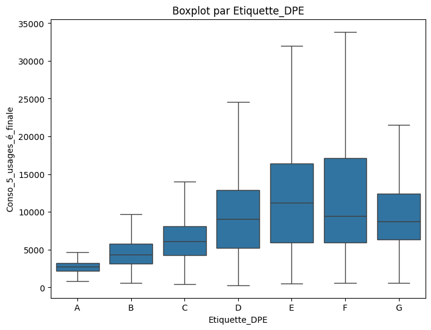

```python
# Visualisation des étiquettes DPE en fonction de la consommation

plt.figure(figsize=(8, 6))
sns.boxplot(x='Etiquette_DPE',
            y='Conso_5_usages_é_finale',
            data=df_dpe, showfliers=False,
            order=sorted(df_dpe['Etiquette_DPE'].unique()))
plt.title('Boxplot par Etiquette_DPE')
plt.show()
```

### Remarque :

```python
# Proportion Type batiment
df_dpe["Type_bâtiment"].value_counts(normalize=True)*100
```

```
Type_bâtiment
appartement    93.604035
maison          6.318254
immeuble        0.077710
Name: proportion, dtype: float64
```

```python
# Proportion Classe_inertie_bâtiment
df_dpe["Classe_inertie_bâtiment"].value_counts(normalize=True)*100
```

```
Classe_inertie_bâtiment
Moyenne        32.268266
Lourde         27.791867
Légère         23.477045
Très lourde    16.462822
Name: proportion, dtype: float64
```

```python
# Proportion Type_énergie_principale_chauffage
df_dpe["Type_énergie_principale_chauffage"].value_counts(normalize=True)*100
```

```
Type_énergie_principale_chauffage
Gaz naturel                                                     47.525600
Électricité                                                     34.439576
Réseau de Chauffage urbain                                      16.223672
Fioul domestique                                                 0.701950
Bois – Bûches                                                    0.493176
Bois – Granulés (pellets) ou briquettes                          0.466191
GPL                                                              0.083794
Propane                                                          0.043672
Bois – Plaquettes d’industrie                                    0.010652
Bois – Plaquettes forestières                                    0.007811
Charbon                                                          0.003551
Électricité d'origine renouvelable utilisée dans le bâtiment     0.000355
Name: proportion, dtype: float64
```

```python
# Proportion Isolation_toiture_(0/1)
df_dpe["Isolation_toiture_(0/1)"].value_counts(normalize=True)*100
```

```
Isolation_toiture_(0/1)
False    67.930654
True     32.069346
Name: proportion, dtype: float64
```

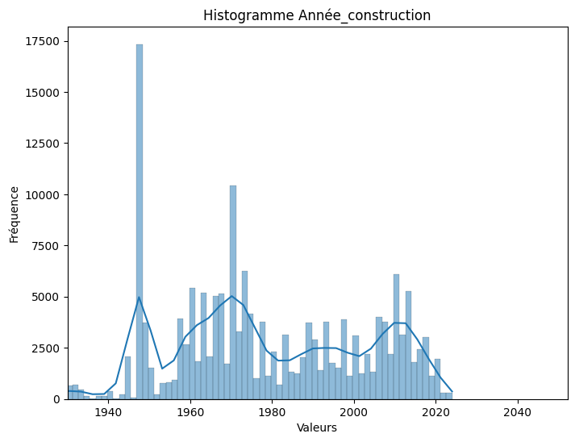

```python
# Viz variable Année_construction
plt.figure(figsize=(8,6))
sns.histplot(df_dpe["Année_construction"], kde=True)
plt.title("Histogramme Année_construction")
plt.xlabel("Valeurs")
plt.ylabel("Fréquence")
plt.xlim(left = 1930)
plt.show()
```

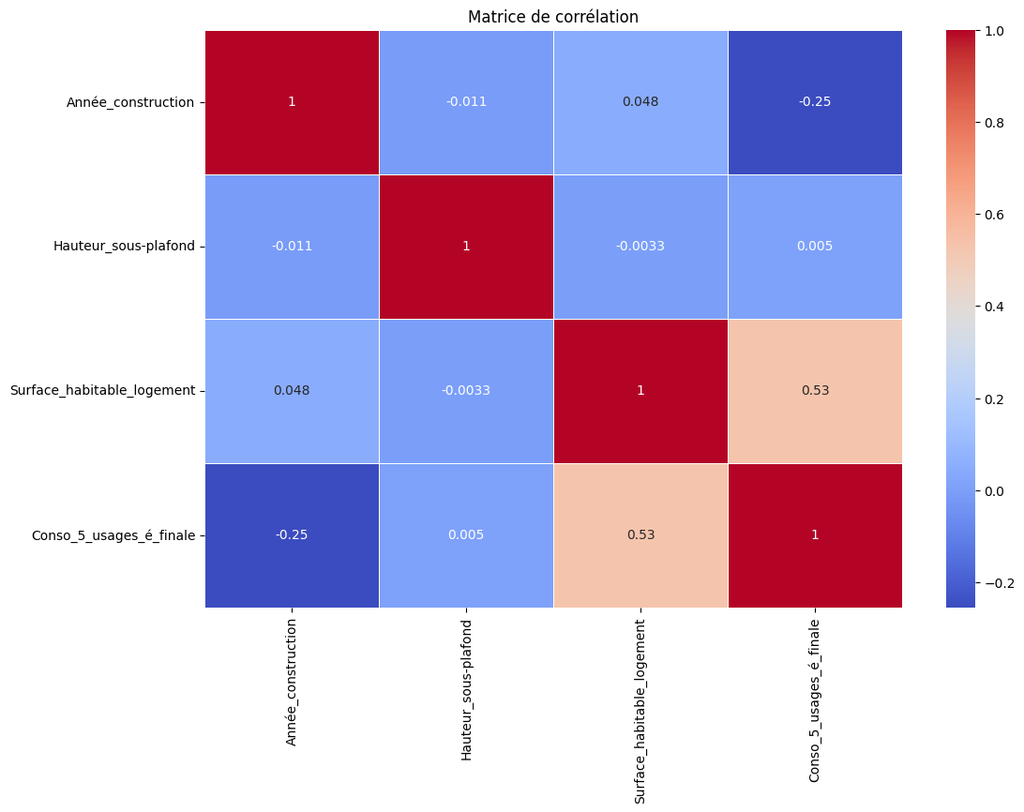

```python
#Matrice des corrélations variables quanti
corr_matrix = df_dpe[["Année_construction", "Hauteur_sous-plafond", "Surface_habitable_logement", "Conso_5_usages_é_finale"]].corr()

#Affichage de la matrice de corrélation
plt.figure(figsize=(12,8))
sns.heatmap(data=corr_matrix,
            annot=True,
            cmap = "coolwarm",
            linewidths=0.5)
plt.title('Matrice de corrélation')
plt.show()
```

```
(0.0, 100000.0)
```

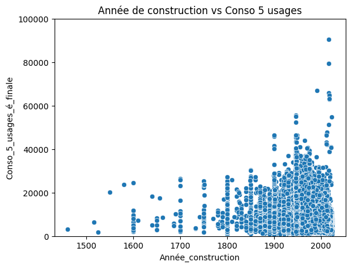

```python
#Viz Année construction vs Conso 5 usages
sns.scatterplot(data=df_dpe,
                x = df_dpe["Année_construction"],
                y = df_dpe["Conso_5_usages_é_finale"])
plt.title("Année de construction vs Conso 5 usages")
plt.ylim(0,100000)
plt.show()
```

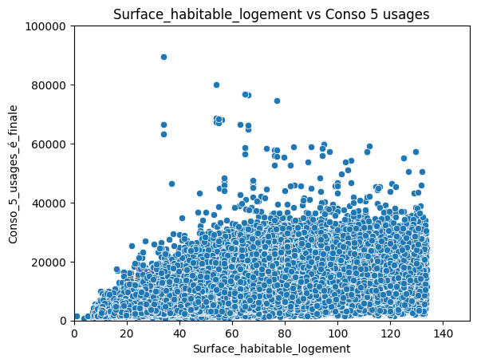

```python
#Viz Surface_habitable_logement vs Conso 5 usages
sns.scatterplot(data=df_dpe,
                x = df_dpe["Surface_habitable_logement"],
                y = df_dpe["Conso_5_usages_é_finale"])
plt.title("Surface_habitable_logement vs Conso 5 usages")
plt.ylim(0,100000)
plt.xlim((0, 150))
plt.show()
```

```
(0.0, 6.0)
```

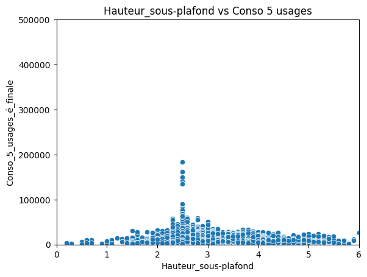

```python
#Viz Hauteur_sous-plafond vs Conso 5 usages
sns.scatterplot(data=df_dpe,
                x = df_dpe["Hauteur_sous-plafond"],
                y = df_dpe["Conso_5_usages_é_finale"])
plt.title("Hauteur_sous-plafond vs Conso 5 usages")
plt.ylim(0,500000)
plt.xlim((0,6))
plt.show()
```

## 3.2 Target

```
(0.0, 30000.0)
```

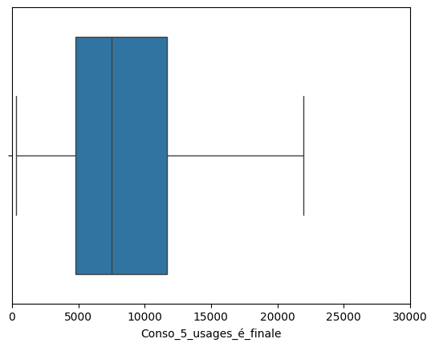

```python
# Visualisation de la cible
sns.boxplot(data=df_dpe,
            x=df_dpe["Conso_5_usages_é_finale"],
            showfliers = False)
plt.xlim((0, 30000))
plt.show()
```

# 4. Prétraitement des données

## 4.1 Suppression des outliers

```python
# Supression des outliers avec la méthode des quartiles [q1 - 1.5 * IQR , q3 + 1.5 * IQR]

#Sélection des vars quanti
df_quanti = df_dpe.select_dtypes(include=['number'])

#Calcul du IQR pour chaque colonne
Q1 = df_quanti.quantile(0.025)
Q3 = df_quanti.quantile(0.975)
IQR = Q3-Q1

#Filtrage des données sans outliers
df_dpe_filtered = df_dpe[~((df_quanti < (Q1 - 1.5 * IQR)) | (df_quanti > (Q3 + 1.5 * IQR))).any(axis=1)]

df_dpe_filtered.describe()
```

|  | Année_construction | Hauteur_sous-plafond | Surface_habitable_logement | Code_postal_(BAN) | Conso_5_usages_é_finale |
| --- | --- | --- | --- | --- | --- |
| count | 174288.000000 | 289969.000000 | 289599.000000 | 289969.000000 | 289967.000000 |
| mean | 1976.078462 | 2.584857 | 59.950143 | 69176.602351 | 8787.737198 |
| std | 28.094469 | 0.231603 | 24.200983 | 223.070127 | 5382.901515 |
| min | 1732.000000 | 1.100000 | 1.000000 | 69001.000000 | 306.300000 |
| 25% | 1959.000000 | 2.500000 | 42.600000 | 69006.000000 | 4791.300000 |
| 50% | 1974.000000 | 2.500000 | 61.000000 | 69100.000000 | 7504.900000 |
| 75% | 1999.000000 | 2.500000 | 76.000000 | 69290.000000 | 11635.600000 |
| max | 2024.000000 | 4.600000 | 133.700000 | 69970.000000 | 52700.600000 |

```python
df_dpe_filtered.shape
```

```
(289969, 10)
```

## 4.2 Gestion des valeurs manquantes

```python
# Nombres de valeurs manquantes
df_dpe_filtered.isnull().sum()
```

```
Etiquette_DPE                             0
Type_bâtiment                             0
Année_construction                   115681
Classe_inertie_bâtiment                1791
Hauteur_sous-plafond                      0
Surface_habitable_logement              370
Type_énergie_principale_chauffage      9161
Isolation_toiture_(0/1)              121553
Code_postal_(BAN)                         0
Conso_5_usages_é_finale                   2
dtype: int64
```

```python
#On enlève les obsevrations où la consommation n'est pas renseignée
df_dpe_filtered = df_dpe_filtered.dropna(subset=["Conso_5_usages_é_finale"])
df_dpe_filtered.isnull().sum()
```

```
Etiquette_DPE                             0
Type_bâtiment                             0
Année_construction                   115681
Classe_inertie_bâtiment                1791
Hauteur_sous-plafond                      0
Surface_habitable_logement              370
Type_énergie_principale_chauffage      9161
Isolation_toiture_(0/1)              121553
Code_postal_(BAN)                         0
Conso_5_usages_é_finale                   0
dtype: int64
```

```python
#On enlève les "immeubles"
df_dpe_filtered = df_dpe_filtered[df_dpe['Type_bâtiment'] != 'immeuble']
```

```python
#Check des types de logement ou l'isolation du toit n'est pas rempli
test = df_dpe_filtered[(df_dpe_filtered["Isolation_toiture_(0/1)"] != 0) & (df_dpe_filtered["Isolation_toiture_(0/1)"] != 1)]
test["Type_bâtiment"].value_counts(normalize=True)
```

```
Type_bâtiment
appartement    0.936957
maison         0.063043
Name: proportion, dtype: float64
```

```python
#On impute une catégorie "Inconnue" pour les NA de l'isolation_toiture, pour pas perdre d'information.
df_dpe_filtered["Isolation_toiture_(0/1)"] = df_dpe_filtered["Isolation_toiture_(0/1)"].fillna("Inconnue")
df_dpe_filtered["Isolation_toiture_(0/1)"] = df_dpe_filtered["Isolation_toiture_(0/1)"].str.strip()
df_dpe_filtered.isnull().sum()
```

```
Etiquette_DPE                             0
Type_bâtiment                             0
Année_construction                   115650
Classe_inertie_bâtiment                1791
Hauteur_sous-plafond                      0
Surface_habitable_logement              164
Type_énergie_principale_chauffage      9160
Isolation_toiture_(0/1)                   0
Code_postal_(BAN)                         0
Conso_5_usages_é_finale                   0
dtype: int64
```

```python
#Om impute la moyenne pour les NA de l'année de construction
df_dpe_filtered["Année_construction"] = df_dpe_filtered["Année_construction"].fillna(df_dpe_filtered["Année_construction"].mean())
df_dpe_filtered.isnull().sum()
```

```
Etiquette_DPE                           0
Type_bâtiment                           0
Année_construction                      0
Classe_inertie_bâtiment              1791
Hauteur_sous-plafond                    0
Surface_habitable_logement            164
Type_énergie_principale_chauffage    9160
Isolation_toiture_(0/1)                 0
Code_postal_(BAN)                       0
Conso_5_usages_é_finale                 0
dtype: int64
```

```python
#Om impute la moyenne pour les NA de la surface
df_dpe_filtered["Surface_habitable_logement"] = df_dpe_filtered["Surface_habitable_logement"].fillna(df_dpe_filtered["Surface_habitable_logement"].mean())
df_dpe_filtered.isnull().sum()
```

```
Etiquette_DPE                           0
Type_bâtiment                           0
Année_construction                      0
Classe_inertie_bâtiment              1791
Hauteur_sous-plafond                    0
Surface_habitable_logement              0
Type_énergie_principale_chauffage    9160
Isolation_toiture_(0/1)                 0
Code_postal_(BAN)                       0
Conso_5_usages_é_finale                 0
dtype: int64
```

```python
#Om impute le mode pour les NA de classe Type_énergie_principale_chauffage
df_dpe_filtered["Type_énergie_principale_chauffage"] = df_dpe_filtered["Type_énergie_principale_chauffage"].fillna(df_dpe_filtered["Type_énergie_principale_chauffage"].mode()[0])
df_dpe_filtered.isnull().sum()
```

```
Etiquette_DPE                           0
Type_bâtiment                           0
Année_construction                      0
Classe_inertie_bâtiment              1791
Hauteur_sous-plafond                    0
Surface_habitable_logement              0
Type_énergie_principale_chauffage       0
Isolation_toiture_(0/1)                 0
Code_postal_(BAN)                       0
Conso_5_usages_é_finale                 0
dtype: int64
```

```python
#Om impute le mode pour les NA de classe Classe_inertie_bâtiment
df_dpe_filtered["Classe_inertie_bâtiment"] = df_dpe_filtered["Classe_inertie_bâtiment"].fillna(df_dpe_filtered["Classe_inertie_bâtiment"].mode()[0])
df_dpe_filtered.isnull().sum()
```

```
Etiquette_DPE                        0
Type_bâtiment                        0
Année_construction                   0
Classe_inertie_bâtiment              0
Hauteur_sous-plafond                 0
Surface_habitable_logement           0
Type_énergie_principale_chauffage    0
Isolation_toiture_(0/1)              0
Code_postal_(BAN)                    0
Conso_5_usages_é_finale              0
dtype: int64
```

## 4.3 Encodage et Train / Test Split

```python
#Encodage des variables catégorielles
from sklearn.preprocessing import LabelEncoder

label_encoder = LabelEncoder()
df_enc = df_dpe_filtered.copy()

df_enc['Etiquette_DPE'] = label_encoder.fit_transform(df_enc['Etiquette_DPE'])
df_enc['Type_bâtiment'] = label_encoder.fit_transform(df_enc['Type_bâtiment'])
df_enc['Classe_inertie_bâtiment'] = label_encoder.fit_transform(df_enc['Classe_inertie_bâtiment'])
df_enc['Type_énergie_principale_chauffage'] = label_encoder.fit_transform(df_enc['Type_énergie_principale_chauffage'])
df_enc['Isolation_toiture_(0/1)'] = label_encoder.fit_transform(df_enc['Isolation_toiture_(0/1)'])
```

```python
df_enc["Conso_5_usages_é_finale"].isnull().value_counts()
```

```
Conso_5_usages_é_finale
False    289967
Name: count, dtype: int64
```

```python
#Séparation variables explicatives et variable cible
X = df_enc[var_explicatives]
y = df_enc[target]

#Train / Test Split
from sklearn.model_selection import train_test_split
X_train, X_test, y_train, y_test = train_test_split(X, y, test_size=0.3, random_state=0)

X_train.shape
```

```
(202976, 9)
```

# 5. Modèle

## 5.1 Arbre de régression

```python
from sklearn.tree import DecisionTreeRegressor
modele_arbre = DecisionTreeRegressor()
modele_arbre = modele_arbre.fit(X_train, y_train)
```

```python
y_pred_arbre = modele_arbre.predict(X_test)
y_pred_arbre
```

```
array([ 8092.8       , 13323.9       , 16027.00882353, ...,
       11016.8       , 13573.8       , 16693.        ])
```

```python
from sklearn.metrics import r2_score, mean_squared_error
print(f"RMSE : {mean_squared_error( y_true=y_test, y_pred=y_pred_arbre, squared = False)}")
print(f"R2 : {r2_score(y_true=y_test, y_pred=y_pred_arbre)}")
```

```
RMSE : 1826.9069145060782
R2 : 0.8850372313955839
```

### Remarque :

- RMSE : On obtient une RMSE de 1827 environ. Cela signifie que l'erreur moyenne de notre modèle est de 1827 kWhef/an. Quand on sait que les valeurs de la variable cible varient entre 300 et 50 000, on considère que l'erreur moyenne est acceptable.
- R2 : Une valeur de 0.89 au R2 nous indique que notre modèle explique 89% de la variablité de la variabel cible. Cela nous indique que notre modèle est performant car proche de 1.

## 5.2 GridSearch CV

```python
#Défini nos paramètres
param_grid = {
    'max_depth': [2, 10, 20],
    'min_samples_split': [2, 10, 20],
    'min_samples_leaf': [1, 5, 10]
}

# Calculer le nombre de valeurs pour chaque paramètre
total_combinaisons = (
    len(param_grid["max_depth"])*
    len(param_grid["min_samples_split"])*
    len(param_grid["min_samples_leaf"])
)

print(f"Nombre total de modèles à tester: {total_combinaisons}")
```

```
Nombre total de modèles à tester: 27
```

```python
#Grid search validation croisé
from sklearn.model_selection import GridSearchCV

model_arbre_grid = DecisionTreeRegressor()
model_arbre_grid = GridSearchCV(model_arbre_grid, param_grid, scoring = 'r2', verbose = 2, cv = 5)
model_arbre_grid.fit(X_train, y_train)
```

```
Fitting 5 folds for each of 27 candidates, totalling 135 fits
[CV] END max_depth=2, min_samples_leaf=1, min_samples_split=2; total time=   0.3s
[CV] END max_depth=2, min_samples_leaf=1, min_samples_split=2; total time=   0.1s
[CV] END max_depth=2, min_samples_leaf=1, min_samples_split=2; total time=   0.2s
[CV] END max_depth=2, min_samples_leaf=1, min_samples_split=2; total time=   0.1s
[CV] END max_depth=2, min_samples_leaf=1, min_samples_split=2; total time=   0.2s
[CV] END max_depth=2, min_samples_leaf=1, min_samples_split=10; total time=   0.2s
[CV] END max_depth=2, min_samples_leaf=1, min_samples_split=10; total time=   0.2s
[CV] END max_depth=2, min_samples_leaf=1, min_samples_split=10; total time=   0.1s
[CV] END max_depth=2, min_samples_leaf=1, min_samples_split=10; total time=   0.1s
[CV] END max_depth=2, min_samples_leaf=1, min_samples_split=10; total time=   0.1s
[CV] END max_depth=2, min_samples_leaf=1, min_samples_split=20; total time=   0.1s
[CV] END max_depth=2, min_samples_leaf=1, min_samples_split=20; total time=   0.1s
[CV] END max_depth=2, min_samples_leaf=1, min_samples_split=20; total time=   0.1s
[CV] END max_depth=2, min_samples_leaf=1, min_samples_split=20; total time=   0.1s
[CV] END max_depth=2, min_samples_leaf=1, min_samples_split=20; total time=   0.1s
[CV] END max_depth=2, min_samples_leaf=5, min_samples_split=2; total time=   0.1s
[CV] END max_depth=2, min_samples_leaf=5, min_samples_split=2; total time=   0.1s
[CV] END max_depth=2, min_samples_leaf=5, min_samples_split=2; total time=   0.1s
[CV] END max_depth=2, min_samples_leaf=5, min_samples_split=2; total time=   0.1s
[CV] END max_depth=2, min_samples_leaf=5, min_samples_split=2; total time=   0.1s
[CV] END max_depth=2, min_samples_leaf=5, min_samples_split=10; total time=   0.1s
[CV] END max_depth=2, min_samples_leaf=5, min_samples_split=10; total time=   0.1s
[CV] END max_depth=2, min_samples_leaf=5, min_samples_split=10; total time=   0.1s
[CV] END max_depth=2, min_samples_leaf=5, min_samples_split=10; total time=   0.1s
[CV] END max_depth=2, min_samples_leaf=5, min_samples_split=10; total time=   0.3s
[CV] END max_depth=2, min_samples_leaf=5, min_samples_split=20; total time=   0.1s
[CV] END max_depth=2, min_samples_leaf=5, min_samples_split=20; total time=   0.1s
[CV] END max_depth=2, min_samples_leaf=5, min_samples_split=20; total time=   0.1s
[CV] END max_depth=2, min_samples_leaf=5, min_samples_split=20; total time=   0.1s
[CV] END max_depth=2, min_samples_leaf=5, min_samples_split=20; total time=   0.1s
[CV] END max_depth=2, min_samples_leaf=10, min_samples_split=2; total time=   0.1s
[CV] END max_depth=2, min_samples_leaf=10, min_samples_split=2; total time=   0.1s
[CV] END max_depth=2, min_samples_leaf=10, min_samples_split=2; total time=   0.1s
[CV] END max_depth=2, min_samples_leaf=10, min_samples_split=2; total time=   0.1s
[CV] END max_depth=2, min_samples_leaf=10, min_samples_split=2; total time=   0.1s
[CV] END max_depth=2, min_samples_leaf=10, min_samples_split=10; total time=   0.1s
[CV] END max_depth=2, min_samples_leaf=10, min_samples_split=10; total time=   0.1s
[CV] END max_depth=2, min_samples_leaf=10, min_samples_split=10; total time=   0.1s
[CV] END max_depth=2, min_samples_leaf=10, min_samples_split=10; total time=   0.1s
```

[output cut: 81 more lines]

```
[CV] END max_depth=20, min_samples_leaf=10, min_samples_split=2; total time=   0.9s
[CV] END max_depth=20, min_samples_leaf=10, min_samples_split=2; total time=   0.8s
[CV] END max_depth=20, min_samples_leaf=10, min_samples_split=2; total time=   0.7s
[CV] END max_depth=20, min_samples_leaf=10, min_samples_split=2; total time=   0.6s
[CV] END max_depth=20, min_samples_leaf=10, min_samples_split=2; total time=   0.9s
[CV] END max_depth=20, min_samples_leaf=10, min_samples_split=10; total time=   0.8s
[CV] END max_depth=20, min_samples_leaf=10, min_samples_split=10; total time=   0.7s
[CV] END max_depth=20, min_samples_leaf=10, min_samples_split=10; total time=   0.9s
[CV] END max_depth=20, min_samples_leaf=10, min_samples_split=10; total time=   0.9s
[CV] END max_depth=20, min_samples_leaf=10, min_samples_split=10; total time=   1.1s
[CV] END max_depth=20, min_samples_leaf=10, min_samples_split=20; total time=   0.6s
[CV] END max_depth=20, min_samples_leaf=10, min_samples_split=20; total time=   0.8s
[CV] END max_depth=20, min_samples_leaf=10, min_samples_split=20; total time=   0.5s
[CV] END max_depth=20, min_samples_leaf=10, min_samples_split=20; total time=   0.6s
[CV] END max_depth=20, min_samples_leaf=10, min_samples_split=20; total time=   0.7s
```

```
GridSearchCV(cv=5, estimator=DecisionTreeRegressor(),
             param_grid={'max_depth': [2, 10, 20],
                         'min_samples_leaf': [1, 5, 10],
                         'min_samples_split': [2, 10, 20]},
             scoring='r2', verbose=2)
```

```python
# Meilleur modèle
print("Meilleurs paramètres : " + str(model_arbre_grid.best_estimator_))
print("R2 du meilleur modèle : " + str(model_arbre_grid.best_score_))
```

```
Meilleurs paramètres : DecisionTreeRegressor(max_depth=20, min_samples_leaf=10, min_samples_split=20)
R2 du meilleur modèle : 0.918458183410231
```

## 5.3 Pipeline

```python
#Colonnes numériques et catégorielles / traitement spécifique pour isolation toiture
num_features = ["Année_construction", "Hauteur_sous-plafond", "Surface_habitable_logement"]
iso_feature = ["Isolation_toiture_(0/1)"]
cat_features = ["Etiquette_DPE", "Type_bâtiment", "Classe_inertie_bâtiment", "Type_énergie_principale_chauffage"]
```

```python
#On définit le numerical transformer
num_transformer = Pipeline(steps=[
    ('imputer', SimpleImputer(strategy='median'))
])

#On définit le categorical transformer
cat_transformer = Pipeline(steps=[
    ('imputer', SimpleImputer(strategy='most_frequent')),
    ('encoder', ce.OneHotEncoder(handle_unknown='ignore'))
])

# On définit le preprocessor
preprocessor = ColumnTransformer(
    transformers=[
        ('num', num_transformer, num_features),
        ('cat', cat_transformer, cat_features)
    ]
)

# On définit le pipeline
pipeline = Pipeline(steps=[
    ('preprocessor', preprocessor),
    ('regressor', DecisionTreeRegressor(max_depth=20, min_samples_leaf=10, min_samples_split=20))
])
```

```python
# Pipeline final avec les données encodées et imputées
pipeline.fit(X_train, y_train.values.ravel())

# Sauvegarde du pipeline complet
with open('pipeline_ml_regression.pkl', 'wb') as file:
    pickle.dump(pipeline, file)
```